# Project3

Chris He

2024-04-23

## Introduction

```
## # A tibble: 6 × 25
##    year brand     superbowl_ads_dot_com…¹ youtube_url funny show_product_quickly
##   <dbl> <chr>     <chr>                   <chr>       <lgl> <lgl>
## 1  2018 Toyota    https://superbowl-ads.… https://ww… FALSE FALSE
## 2  2020 Bud Light https://superbowl-ads.… https://ww… TRUE  TRUE
## 3  2006 Bud Light https://superbowl-ads.… https://ww… TRUE  FALSE
## 4  2018 Hynudai   https://superbowl-ads.… https://ww… FALSE TRUE
## 5  2003 Bud Light https://superbowl-ads.… https://ww… TRUE  TRUE
## 6  2020 Toyota    https://superbowl-ads.… https://ww… TRUE  TRUE
## # ℹ abbreviated name: ¹superbowl_ads_dot_com_url
## # ℹ 19 more variables: patriotic <lgl>, celebrity <lgl>, danger <lgl>,
## #   animals <lgl>, use_sex <lgl>, id <chr>, kind <chr>, etag <chr>,
## #   view_count <dbl>, like_count <dbl>, dislike_count <dbl>,
## #   favorite_count <dbl>, comment_count <dbl>, published_at <dttm>,
## #   title <chr>, description <chr>, thumbnail <chr>, channel_title <chr>,
## #   category_id <dbl>
```

The dataset contains 247 observations of 25 variables. A derived boolean variable called `popular` was created using `view_count`, using an arbitrarily selected limit of 200,000 as a marker for a popular commercial video. As commercials ran during the Superbowl are expensive, it makes sense to set the standards of `popular` higher rather than lower. `popular` will be the response variable investigated in this project.

## EDA

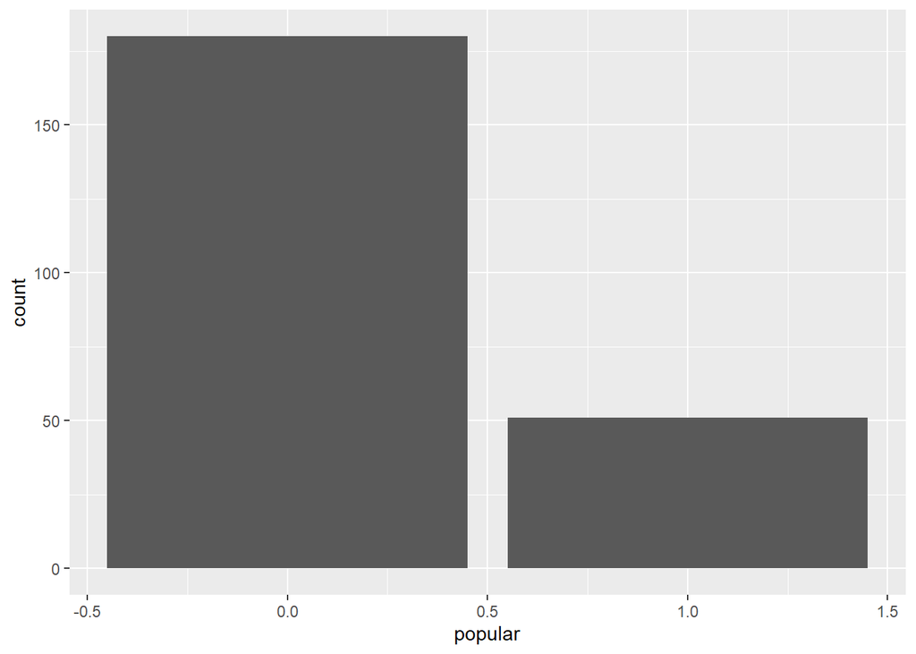

It appears that most of the commercials shown during the Superbowl did not gain popularity. Approximately 50 videos did, while upwards of 175 did not.

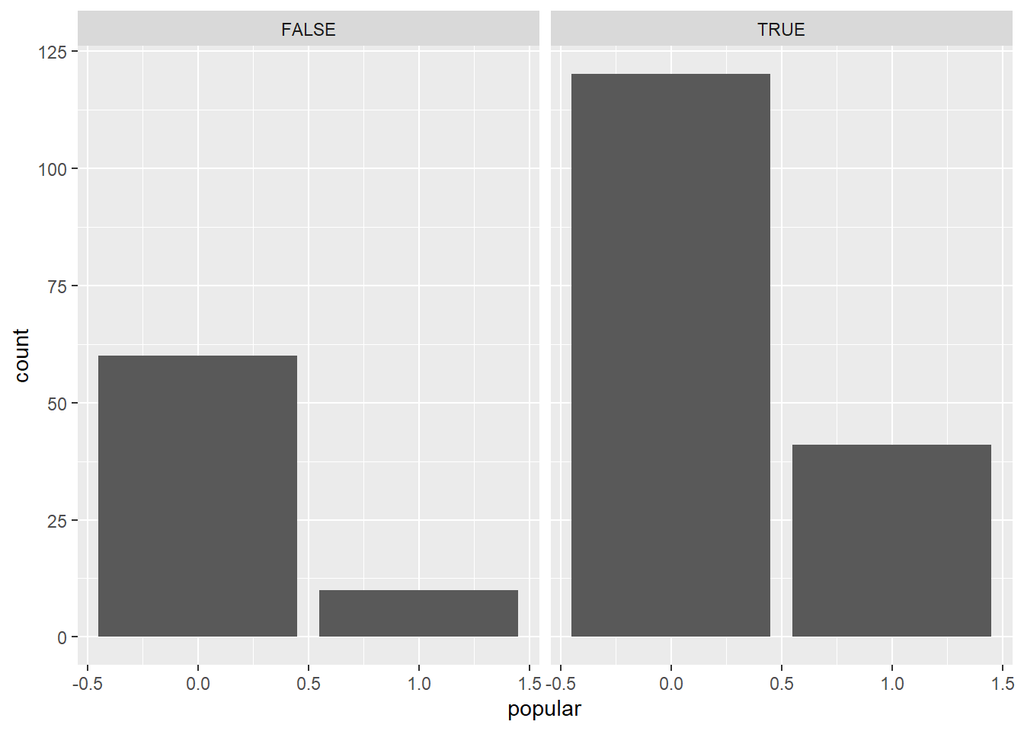

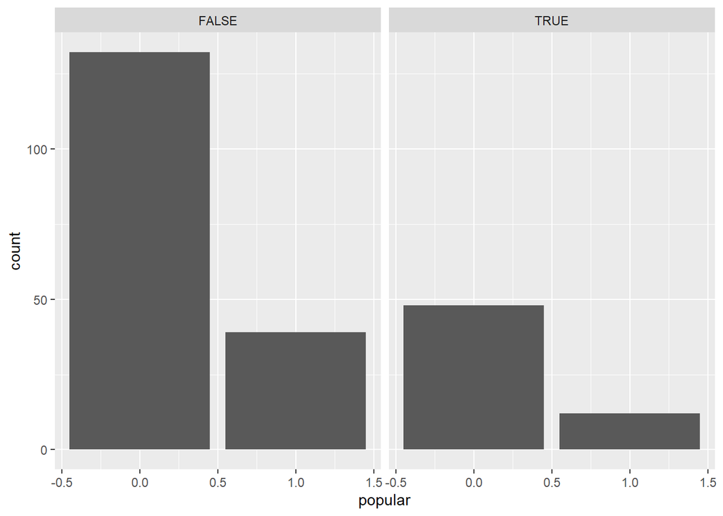

Using sex seems to be relatively unimpactful to the chances of popularity.